# Assignment 6: Local Analysis

Manas Bhatia

2024-12-13

0. Install packages

Install package from github as recommended

```r
here() # important in rmarkdown
```

```
## [1] "C:/Users/mb5327/Documents/EDA/Module4"
```

4. Load data

```r
### station data
stns <- read_csv("Data/GHCND/ghcnd-stations.csv")
stns
```

```
## # A tibble: 124,954 × 9
##    V1             V2    V3     V4 V5    V6                    V7    V8    V9
##    <chr>       <dbl> <dbl>  <dbl> <chr> <chr>                 <chr> <chr> <chr>
##  1 ACW00011604  17.1 -61.8   10.1 <NA>  ST JOHNS COOLIDGE FLD <NA>  <NA>  <NA>
##  2 ACW00011647  17.1 -61.8   19.2 <NA>  ST JOHNS              <NA>  <NA>  <NA>
##  3 AE000041196  25.3  55.5   34   <NA>  SHARJAH INTER. AIRP   GSN   <NA>  41196
##  4 AEM00041194  25.3  55.4   10.4 <NA>  DUBAI INTL            <NA>  <NA>  41194
##  5 AEM00041217  24.4  54.7   26.8 <NA>  ABU DHABI INTL        <NA>  <NA>  41217
##  6 AEM00041218  24.3  55.6  265.  <NA>  AL AIN INTL           <NA>  <NA>  41218
##  7 AF000040930  35.3  69.0 3366   <NA>  NORTH-SALANG          GSN   <NA>  40930
##  8 AFM00040938  34.2  62.2  977.  <NA>  HERAT                 <NA>  <NA>  40938
##  9 AFM00040948  34.6  69.2 1791.  <NA>  KABUL INTL            <NA>  <NA>  40948
## 10 AFM00040990  31.5  65.8 1010   <NA>  KANDAHAR AIRPORT      <NA>  <NA>  40990
## # ℹ 124,944 more rows
```

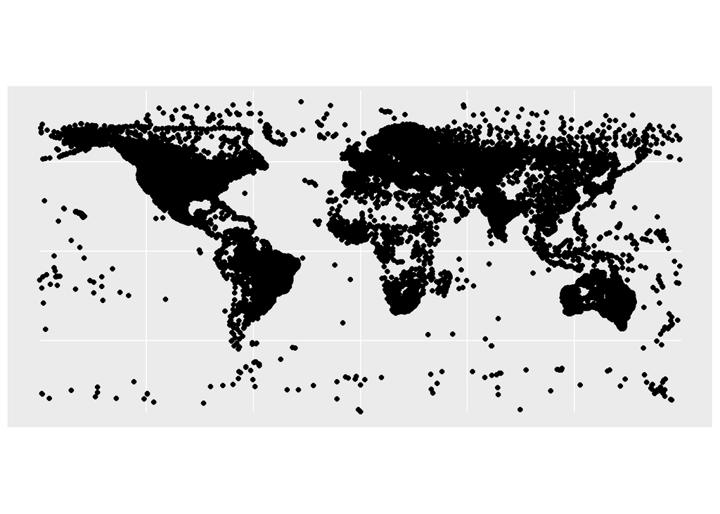

```r
names(stns) <- c("ID", "LAT", "LON", "ELEV",
                 "ST", "NAME", "GSN", "HCN", "WMOID")

stns %>% st_as_sf(coords=c("LON", "LAT"), crs = 4326) %>%
    ggplot() +
    geom_sf()
```

```r
stnsFilter <- stns %>%
    filter(str_detect(ID, "^US"))

## Inventory Data has variables for stations
inv <- read_csv("Data/GHCND/ghcnd-inventory.csv")
names(inv) <- c("ID", "LAT", "LON", "ELEM",
                "FIRST", "LAST")
```

5. Filter and Join data

```r
# Filter inventory data for stations reporting both TMAX and TMIN for 2022
invFilter <- inv %>%
  filter(
    str_detect(ELEM, "TMAX|TMIN"),  # Include both TMAX and TMIN
    FIRST <= 2022,                  # Ensure data starts on or before 2022
    LAST >= 2022                    # Ensure data ends on or after 2022
  ) %>%
  group_by(ID) %>%                  # Group by station ID
  summarize(                        # Summarize available elements
    hasTMAX = any(ELEM == "TMAX"),
    hasTMIN = any(ELEM == "TMIN")
  ) %>%
  filter(hasTMAX & hasTMIN)         # Keep only stations with both TMAX and TMIN

# Join filtered stations with station metadata
joinDF <- inner_join(stnsFilter, invFilter, by = "ID") %>%
  mutate(fileNameCSV = paste0(ID, ".csv"))


joinDF_subset <- joinDF %>% head(500)

joinDF_subset
```

```
## # A tibble: 500 × 12
##    ID            LAT   LON  ELEV ST    NAME    GSN   HCN   WMOID hasTMAX hasTMIN
##    <chr>       <dbl> <dbl> <dbl> <chr> <chr>   <chr> <chr> <chr> <lgl>   <lgl>
##  1 USC00010063  34.2 -87.2 240.  AL    ADDISON <NA>  <NA>  <NA>  TRUE    TRUE
##  2 USC00010160  32.9 -86.0 201.  AL    ALEXAN… <NA>  <NA>  <NA>  TRUE    TRUE
##  3 USC00010178  33.1 -88.2  59.4 AL    ALICEV… <NA>  <NA>  <NA>  TRUE    TRUE
##  4 USC00010260  35.0 -87.4 232.  AL    LEXING… <NA>  <NA>  <NA>  TRUE    TRUE
##  5 USC00010390  34.8 -87.0 210   AL    ATHENS  <NA>  <NA>  <NA>  TRUE    TRUE
##  6 USC00010402  31.2 -87.4  91.4 AL    ATMORE  <NA>  <NA>  <NA>  TRUE    TRUE
##  7 USC00010425  32.6 -85.5 166.  AL    AUBURN… <NA>  <NA>  <NA>  TRUE    TRUE
##  8 USC00010505  33.5 -87.4  85.3 AL    BANKHE… <NA>  <NA>  <NA>  TRUE    TRUE
##  9 USC00010583  30.9 -87.8  82.6 AL    BAY MI… <NA>  <NA>  <NA>  TRUE    TRUE
## 10 USC00010655  34.7 -86.9 184.  AL    BELLE … <NA>  <NA>  <NA>  TRUE    TRUE
## # ℹ 490 more rows
## # ℹ 1 more variable: fileNameCSV <chr>
```

6. Example of one file

```r
dfSample <- read_csv(here("Data/daily-summaries-latest", joinDF$fileNameCSV[1]))
dfSample
```

```
## # A tibble: 15,762 × 34
##    STATION   DATE       LATITUDE LONGITUDE ELEVATION NAME   PRCP PRCP_ATTRIBUTES
##    <chr>     <date>        <dbl>     <dbl>     <dbl> <chr> <dbl> <chr>
##  1 USC00010… 1938-03-01     34.2     -87.2      240. ADDI…     0 P,,6,
##  2 USC00010… 1938-03-02     34.2     -87.2      240. ADDI…     0 P,,6,
##  3 USC00010… 1938-03-03     34.2     -87.2      240. ADDI…    97 ,,6,
##  4 USC00010… 1938-03-04     34.2     -87.2      240. ADDI…     0 P,,6,
##  5 USC00010… 1938-03-05     34.2     -87.2      240. ADDI…    97 ,,6,
##  6 USC00010… 1938-03-06     34.2     -87.2      240. ADDI…     0 P,,6,
##  7 USC00010… 1938-03-07     34.2     -87.2      240. ADDI…     0 P,,6,
##  8 USC00010… 1938-03-08     34.2     -87.2      240. ADDI…     0 P,,6,
##  9 USC00010… 1938-03-09     34.2     -87.2      240. ADDI…   127 ,,6,
## 10 USC00010… 1938-03-10     34.2     -87.2      240. ADDI…   424 ,,6,
## # ℹ 15,752 more rows
## # ℹ 26 more variables: SNOW <dbl>, SNOW_ATTRIBUTES <chr>, SNWD <dbl>,
## #   SNWD_ATTRIBUTES <chr>, TMAX <dbl>, TMAX_ATTRIBUTES <chr>, TMIN <dbl>,
## #   TMIN_ATTRIBUTES <chr>, DAPR <dbl>, DAPR_ATTRIBUTES <chr>, MDPR <dbl>,
## #   MDPR_ATTRIBUTES <chr>, TOBS <dbl>, TOBS_ATTRIBUTES <chr>, WESD <lgl>,
## #   WESD_ATTRIBUTES <lgl>, WESF <dbl>, WESF_ATTRIBUTES <chr>, WT04 <lgl>,
## #   WT04_ATTRIBUTES <lgl>, WT05 <lgl>, WT05_ATTRIBUTES <lgl>, WT06 <dbl>, …
```

```r
avgTempDiff <- dfSample %>%
    mutate(year = year(DATE)) %>%
    group_by(STATION, year) %>%
    summarize(avgTempDiff = mean(TMAX - TMIN, na.rm = TRUE))
```

7. Function for multiple files

```r
## function to read over mulitiple files
avgTempDiffFunc <- function(fileName){
    # fileName
    fileN <- here("Data/daily-summaries-latest/", fileName)

    if(file.exists(fileN)){
        dfSample <- read_csv(here("Data/daily-summaries-latest/", fileName))

        # Check for missing columns
        if (!("TMAX" %in% colnames(dfSample)) | !("TMIN" %in% colnames(dfSample))) {
            warning(paste("Skipping file due to missing columns:", fileName))
            return(NULL)
        }

      avgTempDiff <- dfSample %>%
            mutate(year = year(DATE)) %>%
            group_by(STATION, year) %>%
            summarize(avgTempDiff = mean(TMAX - TMIN, na.rm = TRUE),
                      maxTemp = mean(TMAX, na.rm = TRUE),
                      minTemp = mean(TMIN, na.rm = TRUE)) %>%
            ungroup()
        return(avgTempDiff)
    } else {
        warning(paste("File does not exist:", fileName))
        return(NULL)
    }
}



avgTempDF <- joinDF_subset %>% pull(fileNameCSV) %>%
    purrr::map_dfr(~avgTempDiffFunc(.))
write_csv(avgTempDF, "Data/avgTempDFNY.csv")
```

8. Join back- Combine other info

```r
## join back
colnames(avgTempDF)
```

```
## [1] "STATION"     "year"        "avgTempDiff" "maxTemp"     "minTemp"
```

```r
colnames(joinDF)
```

```
##  [1] "ID"          "LAT"         "LON"         "ELEV"        "ST"
##  [6] "NAME"        "GSN"         "HCN"         "WMOID"       "hasTMAX"
## [11] "hasTMIN"     "fileNameCSV"
```

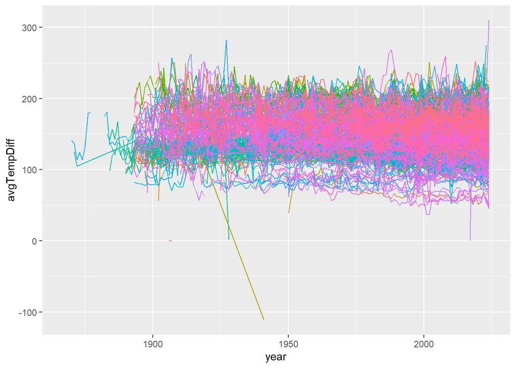

```r
combDF <- avgTempDF %>%
  left_join(joinDF_subset, by = c("STATION" = "ID"))

ggplot(combDF) +
    geom_line(aes(x= year, y = avgTempDiff, group = STATION, color = STATION), show.legend = FALSE)
```

9. Load the raster data

```r
ntl <- raster::raster("Data/Nightime_lights/BlackMarble_2016_3km_geo.tif")
grump <- raster::raster("../Module 1/Data/Urban/urbanization-2010.tiff")
lcz <- raster::raster("Data/USA_LCZ/CONUS_LCZ_map_NLCD_v1.0.tif/CONUS_LCZ_map_NLCD_v1.0.tif")
unPop <- raster::raster("../Module 1/Data/Population/popmean-2010.tiff")
```

10. Add raster data (joined) to a new variable

```r
rastJoin <- joinDF_subset %>% st_as_sf(coords= c("LON", "LAT"), crs = 4326) %>%
    dplyr::select(ID) %>%
    tidyr::nest(-ID) %>%
    dplyr::mutate(
        ntl = purrr::map(data, ~terra::extract(ntl, .x)),
        grump = purrr::map(data, ~terra::extract(grump, .x)),
        lcz = purrr::map(data, ~terra::extract(lcz, .x)),
        unPop = purrr::map(data, ~terra::extract(unPop, .x))) %>%

    tidyr::unnest(ntl, grump, lcz, unPop)
rastJoin
```

```
## # A tibble: 500 × 6
##    ID          data           ntl grump   lcz unPop
##    <chr>       <list>       <dbl> <dbl> <dbl> <dbl>
##  1 USC00010063 <sf [1 × 1]>    93     1     6    94
##  2 USC00010160 <sf [1 × 1]>   255     2     6   199
##  3 USC00010178 <sf [1 × 1]>   202     1    14   138
##  4 USC00010260 <sf [1 × 1]>    84     1    14    73
##  5 USC00010390 <sf [1 × 1]>   255     2     6   179
##  6 USC00010402 <sf [1 × 1]>    31     2    11     0
##  7 USC00010425 <sf [1 × 1]>   255     2     6   388
##  8 USC00010505 <sf [1 × 1]>    28     1    17     0
##  9 USC00010583 <sf [1 × 1]>   255     2     6   143
## 10 USC00010655 <sf [1 × 1]>    19     1    14    17
## # ℹ 490 more rows
```

11. Add the raster data back to combined DF

```r
stationSF <- combDF %>%
  left_join(rastJoin %>% dplyr::select(ID, ntl, grump), by = c("STATION" = "ID")) %>%
  st_as_sf(coords = c("LON", "LAT"), crs = 4326)
```

12. Plot stationSF

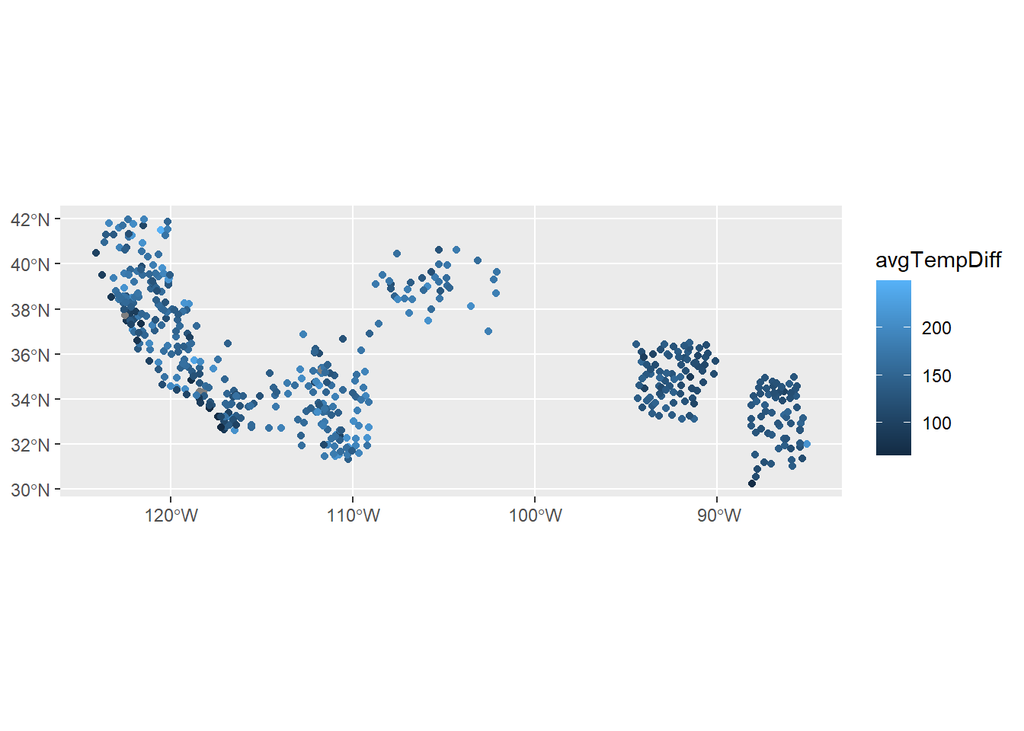

```r
stationSF %>%
    filter(year == 2022) %>%
    ggplot(aes(color = avgTempDiff )) +
    geom_sf()
```

13. Modelling part

```r
stationVarSelect <- stationSF %>%
    filter(year == 2022) %>%
    st_drop_geometry() %>%
    dplyr::select(STATION, avgTempDiff, ELEV, ntl, grump)

stationVarFix <- stationVarSelect%>%
    dplyr::select(-STATION) %>%
    filter(complete.cases(.))
```

14. Create a recipe

```r
# nominal columns
nominal_col <- c("grump")

stationRec <- recipe(avgTempDiff~ELEV + ntl + grump,
                     data= stationVarFix) %>%
    step_impute_mode(all_nominal()) %>%
    step_dummy(all_nominal()) %>%
    step_normalize(all_predictors()) %>%
    step_zv(all_predictors())
```

LINEAR REGRESSION

15. Linear regression

```r
## simple linear regression
lm_spec <- linear_reg() %>%
    set_engine("lm")
```

16. Set workflow

```r
## include this into a workflow
wf <- workflow() %>%
    add_recipe(stationRec) %>%
    add_model(lm_spec)
wf
```

```
## ══ Workflow ════════════════════════════════════════════════════════════════════
## Preprocessor: Recipe
## Model: linear_reg()
##
## ── Preprocessor ────────────────────────────────────────────────────────────────
## 4 Recipe Steps
##
## • step_impute_mode()
## • step_dummy()
## • step_normalize()
## • step_zv()
##
## ── Model ───────────────────────────────────────────────────────────────────────
## Linear Regression Model Specification (regression)
##
## Computational engine: lm
```

17. Fit the model in the wf

```r
lm_fit <- wf %>%
    fit(data = stationVarFix )
```

18. Model diagnostics

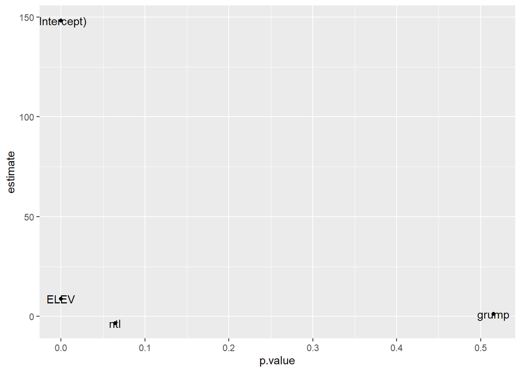

```r
lm_fit %>%
    pull_workflow_fit() %>%
    tidy() %>%
    ggplot(aes(x = p.value, y = estimate)) +
    geom_point() +
    geom_text(aes(label = term))
```

```r
lm_fit
```

```
## ══ Workflow [trained] ══════════════════════════════════════════════════════════
## Preprocessor: Recipe
## Model: linear_reg()
##
## ── Preprocessor ────────────────────────────────────────────────────────────────
## 4 Recipe Steps
##
## • step_impute_mode()
## • step_dummy()
## • step_normalize()
## • step_zv()
##
## ── Model ───────────────────────────────────────────────────────────────────────
##
## Call:
## stats::lm(formula = ..y ~ ., data = data)
##
## Coefficients:
## (Intercept)         ELEV          ntl        grump
##     148.179        8.895       -3.498        1.221
```

RANDOM FOREST MODEL

19. Train random forest

```r
## train random forest
rf_default <-
    rand_forest(mode ="regression")
```

20. Set new workflow

```r
rf_workflow <- workflow() %>%
    add_recipe(stationRec) %>%
    add_model(rf_default)
```

21. Fit new model

```r
rf_fit <- rf_workflow %>%
    fit(stationVarFix)
```

XGBOOST MODEL

22. Xgboost model specification

```r
xgb_spec <- boost_tree(mode = "regression", trees = 1000) %>%
    set_engine("xgboost")
```

23. Xgboost workflow

```r
xgb_workflow <- workflow() %>%
    add_recipe(stationRec) %>%
    add_model(xgb_spec)
```

## fit xgboost model

```r
xgb_fit <- xgb_workflow %>% fit(data = stationVarFix)
```

25. Test results

```r
test_results <-
    stationVarFix %>%
    bind_cols(
        predict(rf_fit, new_data = stationVarFix %>% dplyr::select("ELEV", "ntl", "grump")),
        predict(lm_fit, new_data = stationVarFix %>% dplyr::select("ELEV", "ntl", "grump")),
        predict(xgb_fit, new_data = stationVarFix %>% dplyr::select("ELEV", "ntl", "grump"))
    ) %>%
    rename(
        rf = .pred...5,
        lm = .pred...6,
        xgb = .pred...7
    ) %>%
    mutate(
        rfError = (rf - avgTempDiff)^2,
        lmError = (lm - avgTempDiff)^2,
        xgbError = (xgb - avgTempDiff)^2
    )
test_results
```

```
## # A tibble: 488 × 10
##    avgTempDiff  ELEV   ntl grump    rf    lm   xgb rfError lmError     xgbError
##          <dbl> <dbl> <dbl> <dbl> <dbl> <dbl> <dbl>   <dbl>   <dbl>        <dbl>
##  1        139. 240.     93     1  144.  142.  139.    27.9    11.8 0.00000106
##  2        130. 201.    255     2  136.  138.  130.    41.1    67.4 0.0000552
##  3        128.  59.4   202     1  136.  136.  128.    71.4    61.1 0.000000138
##  4        127. 232.     84     1  143.  142.  127.   267.    249.  0.0000589
##  5        124. 210     255     2  136.  138.  124.   160.    200.  0.000000860
##  6        122.  91.4    31     2  141.  145.  122.   362.    535.  0.0000122
##  7        117. 166.    255     2  135.  137.  117.   341.    434.  0.0000793
##  8        129.  85.3    28     1  143.  143.  129.   197.    180.  0.0000000413
##  9        113.  82.6   255     2  135.  136.  113.   457.    542.  0.0000375
## 10        128. 184.     19     1  143.  144.  128.   228.    266.  0.00000683
## # ℹ 478 more rows
```

26. Calculate RMSE for each model

```r
# Step 2: Calculate RMSE for each model
rmse_results <- test_results %>%
    summarise(
        rfRMSE = sqrt(mean(rfError)),
        lmRMSE = sqrt(mean(lmError)),
        xgbRMSE = sqrt(mean(xgbError))
    )
print(rmse_results)
```

```
## # A tibble: 1 × 3
##   rfRMSE lmRMSE xgbRMSE
##    <dbl>  <dbl>   <dbl>
## 1   24.1   29.2 0.00397
```

27. Best model (lowest RMSE)

```r
# Step 3: Select the best model
best_model <- colnames(rmse_results)[which.min(as.numeric(rmse_results))]
print(paste("Best model:", best_model))
```

```
## [1] "Best model: xgbRMSE"
```

```r
# Step 4: Add residuals to `stationSF`
residuals <- stationSF %>%
    filter(year == 2022) %>%
    filter(complete.cases(avgTempDiff, ELEV, ntl, grump)) %>%
    bind_cols(
        test_results %>% dplyr::select(rfError, lmError, xgbError)
    )

# Use residuals for spatial visualization
print(residuals)
```

```
## Simple feature collection with 488 features and 19 fields
## Geometry type: POINT
## Dimension:     XY
## Bounding box:  xmin: -124.1039 ymin: 30.2506 xmax: -85.09 ymax: 41.9797
## Geodetic CRS:  WGS 84
## # A tibble: 488 × 20
##    STATION  year avgTempDiff maxTemp minTemp  ELEV ST    NAME  GSN   HCN   WMOID
##  * <chr>   <dbl>       <dbl>   <dbl>   <dbl> <dbl> <chr> <chr> <chr> <chr> <chr>
##  1 USC000…  2022        139.    185.    46.0 240.  AL    ADDI… <NA>  <NA>  <NA>
##  2 USC000…  2022        130.    237.   107.  201.  AL    ALEX… <NA>  <NA>  <NA>
##  3 USC000…  2022        128.    242.   114.   59.4 AL    ALIC… <NA>  <NA>  <NA>
##  4 USC000…  2022        127.    220.    93.8 232.  AL    LEXI… <NA>  <NA>  <NA>
##  5 USC000…  2022        124.    225.   102.  210   AL    ATHE… <NA>  <NA>  <NA>
##  6 USC000…  2022        122.    256.   134.   91.4 AL    ATMO… <NA>  <NA>  <NA>
##  7 USC000…  2022        117.    235.   117.  166.  AL    AUBU… <NA>  <NA>  <NA>
##  8 USC000…  2022        129.    236.   117.   85.3 AL    BANK… <NA>  <NA>  <NA>
##  9 USC000…  2022        113.    253.   140.   82.6 AL    BAY … <NA>  <NA>  <NA>
## 10 USC000…  2022        128.    221.    93.0 184.  AL    BELL… <NA>  <NA>  <NA>
## # ℹ 478 more rows
## # ℹ 9 more variables: hasTMAX <lgl>, hasTMIN <lgl>, fileNameCSV <chr>,
## #   ntl <dbl>, grump <dbl>, geometry <POINT [°]>, rfError <dbl>, lmError <dbl>,
## #   xgbError <dbl>
```

28. Raster viz

```r
# Load state boundaries for all U.S. states
usSF <- rnaturalearth::ne_states("United States of America", returnclass = "sf")

# Get the spatial extent of the residuals
usExtents <- raster::extent(as(residuals, "Spatial"))  # Convert residuals to Spatial object if needed

# Create a raster with appropriate resolution
r <- raster::raster(nrow = 500, ncol = 500)
raster::extent(r) <- usExtents

# (Optional) Generate grid if needed for other visualizations
grid <- st_make_grid(usExtents, n = 150)
```

29. Get the interpolated surface of residuals

```r
# Determine the best residual column dynamically
best_residual_col <- paste0(gsub("RMSE", "", best_model), "Error")  # e.g., "rfError", "lmError", "xgbError"

# Create gstat object for interpolation
gs <- gstat(
    formula = as.formula(paste(best_residual_col, "~ 1")),  # Dynamically use the best residual column
    locations = as(residuals, "Spatial"),                  # Convert residuals to Spatial object
    nmax = 5,                                              # Maximum number of neighbors for interpolation
    set = list(idp = 0.7)                                  # Set inverse distance power
)

# Perform interpolation
nn <- interpolate(r, gs)
```

```
## [inverse distance weighted interpolation]
```

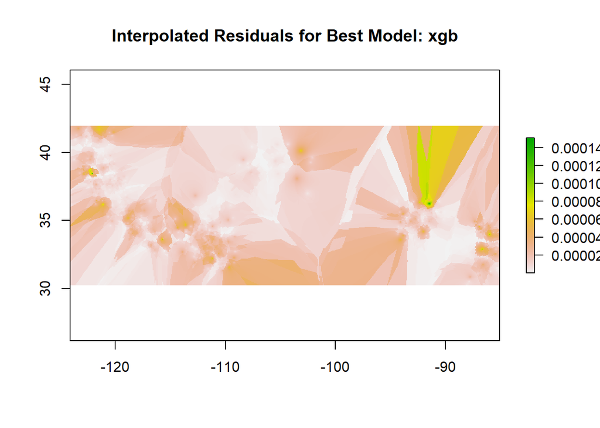

```r
# Plot the interpolated surface
plot(nn, main = paste("Interpolated Residuals for Best Model:", gsub("Error", "", best_residual_col)))
```

30. Look at residuals with the points

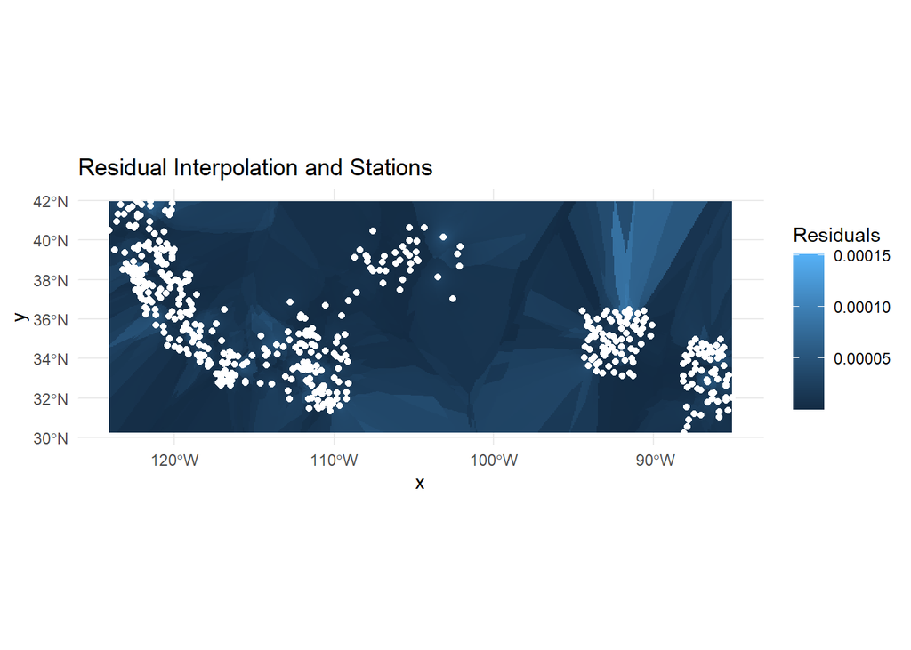

```r
# Convert the interpolated raster to a data frame
residRast <- as.data.frame(nn, xy = TRUE) %>%
    na.omit() %>%
    as_tibble()

# Plot interpolated residuals with points
ggplot() +
    geom_raster(data = residRast, aes(x = x, y = y, fill = var1.pred)) +  # Interpolated residual raster
    geom_sf(data = residuals, color = "white") +                         # Station points
    labs(title = "Residual Interpolation and Stations",
         fill = "Residuals") +
    theme_minimal()
```

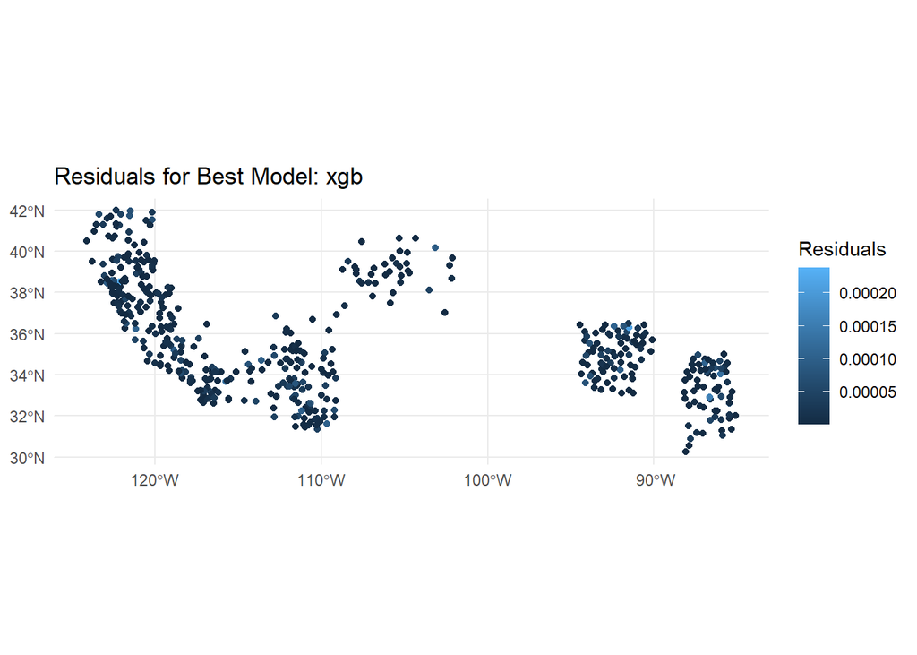

```r
# Plot residuals without the raster, color-coded by best residual column
ggplot() +
    geom_sf(data = residuals, aes(color = !!sym(best_residual_col))) +  # Dynamically select the best residual
    labs(title = paste("Residuals for Best Model:", gsub("Error", "", best_residual_col)),
         color = "Residuals") +
    theme_minimal()
```

RAYSHADER